# Home Credit Modeling Assignment

Nick Goshev, Chris Joyce, Tommaso Pascucci

2024-11-04

# Statement of Business and Analytical Tasks

#### Home Credit faces an issue wherein most of its customers are individuals who have little to no established line of credit. Thus, it is difficult for the company to evaluate potential new customers based on their ability to repay loans taken out through Home Credit, and the company cannot determine the default risk of potential borrowers. The analytical task at hand is to construct a predictive model in order to predict whether or not a new customer is at high risk for defaulting. The outcome is thus a binary variable of two classes: 0 for low risk borrowers, and 1 for high risk borrowers. This predictive model will utilize a supervised approach, in which past financial data that includes the target variable will be used to train the model. The performance of each model will be evaluated based on its respective prediction accuracy compared to a majority classifier.

# Setup and Data Preparation

## Since we have already performed data cleaning and transformation prior to modeling, we comment out the following preparation steps but leave them so as to explain the reasoning behind each step.

```r
#df <- read.csv("application_train.csv",stringsAsFactors = TRUE)
#head(df)
#df <- df[,-1]
```

```r
# Chi^2 testing to remove variables with low association with target

#to_remove <- c()

#for(index in c(2:121)){

#contingency_table <- table(df[,1], df[,index])

#chi_test <- chisq.test(contingency_table)

  #if(chi_test$p.value > 0.01){
    #to_remove <- c(to_remove, index)
  #}
#}

#df_filtered <- df[,-to_remove]
```

```r
# Examining null data and removing columns with extremely high null percentages

#total <- colSums(is.na(df_filtered))

# Calculate the percentage of missing values for each column

#percent <- (colSums(is.na(df_filtered)) / nrow(df_filtered)) * 100

# Combine total and percent into a data frame

#missing_application_train_data <- data.frame(Total = total,Percent = percent)

#missing_application_train_data <- missing_application_train_data[order(-missing_application_train_data$Total), ]

#print(missing_application_train_data)

#kept <- missing_application_train_data %>% filter(Percent < 20) %>% select() %>% labels()

#kept <- unlist(kept[[1]])

#df_filtered <- df[,kept] %>% mutate(TARGET=df$TARGET)
```

```r
# Factoring binary columns

#df_filtered %>% summary()


#unique_counts <- sort(lengths(lapply(df_filtered, unique)))
#binary_columns <- names(unique_counts[unique_counts==2])

#df_filtered[binary_columns] <- lapply(df_filtered[binary_columns], factor)
```

```r
# Removing columns with extremely high correlations amongst each other

#corr_matrix <- cor(df_filtered %>% select(where(is.numeric)), use = "pairwise.complete.obs")

#high_corr <- findCorrelation(corr_matrix, cutoff = 0.95)

#df_filtered <- df_filtered[,-high_corr]
```

```r
# Imputing the missing data for the remaining columns using multiple imputation

#library(mice)

#imputed_data <- mice(df_filtered, m = 5, maxit = 5, seed = 500, ridge = 0.1)

#df_imputed <- complete(imputed_data)

#sum(is.na(df_imputed))
```

# Modeling

```r
df <- read.csv("PracticeProjectImputed.csv",stringsAsFactors = TRUE)
df$TARGET <- df$TARGET %>% factor()
df %>% head()
```

```
##   EXT_SOURCE_3 AMT_REQ_CREDIT_BUREAU_MON AMT_REQ_CREDIT_BUREAU_QRT
## 1    0.1393758                         0                         0
## 2    0.6626378                         0                         0
## 3    0.7295667                         0                         0
## 4    0.5190973                         0                         0
## 5    0.3201634                         0                         0
## 6    0.6212263                         0                         1
##   AMT_REQ_CREDIT_BUREAU_YEAR OBS_30_CNT_SOCIAL_CIRCLE DEF_30_CNT_SOCIAL_CIRCLE
## 1                          1                        2                        2
## 2                          0                        1                        0
## 3                          0                        0                        0
## 4                          1                        2                        0
## 5                          0                        0                        0
## 6                          1                        0                        0
##   DEF_60_CNT_SOCIAL_CIRCLE EXT_SOURCE_2 AMT_ANNUITY CNT_FAM_MEMBERS
```

[output cut: 83 more lines]

```r
# Train/test split

set.seed(100)
inTrain <- createDataPartition(df$TARGET, p=0.7, list=FALSE)

df_train <- df[inTrain,]
df_test <- df[-inTrain,]
```

## Random Forest

```r
# Default

rf_default <- randomForest(TARGET ~ ., data = df_train[,-38])

predictions_train <- predict(rf_default,df_train)
predictions_test <- predict(rf_default,df_test)
```

#### Column 38 is being excluded here due to having 58 levels, random forest does not work with categorical variables over 53 unique levels.

```r
mmetric(df_train$TARGET, predictions_train, metric=c("ACC","TPR","PRECISION","F1"))
```

```
##        ACC       TPR1       TPR2 PRECISION1 PRECISION2        F11        F12
##        100        100        100        100        100        100        100
```

```r
mmetric(df_test$TARGET, predictions_test, metric=c("ACC","TPR","PRECISION","F1"))
```

```
##        ACC       TPR1       TPR2 PRECISION1 PRECISION2        F11        F12
## 91.9340502 99.9858499  0.2417081 91.9444384 60.0000000 95.7966864  0.4814765
```

#### Although the performance was relatively good on the train set the default model is grossly overfitted, and not likely to generalize well. We should adjust hyperparameters to attempt to reconcile this gap between the train and test performance. Also the true positive rate for class 2 is alarmingly low in this case.

```r
# Larger terminal nodes

rf_bignodes <- randomForest(TARGET ~ ., data = df_train[,-38], nodesize=200)
predictions_train <- predict(rf_bignodes,df_train)
predictions_test <- predict(rf_bignodes,df_test)
```

#### These adjustments were done to attempt to reduce overfitting of the model by ensuring a large number of observations in each node.

```r
mmetric(df_train$TARGET, predictions_train, metric=c("ACC","TPR","PRECISION","F1"))
```

```
##        ACC       TPR1       TPR2 PRECISION1 PRECISION2        F11        F12
##   91.92693  100.00000    0.00000   91.92693    0.00000   95.79368    0.00000
```

```r
mmetric(df_test$TARGET, predictions_test, metric=c("ACC","TPR","PRECISION","F1"))
```

```
##        ACC       TPR1       TPR2 PRECISION1 PRECISION2        F11        F12
##   91.92755  100.00000    0.00000   91.92755    0.00000   95.79401    0.00000
```

#### The test set has very similar performance, but performance is slightly lower on train. The accuracy for train and test was extremely similar, which indicates that the model generalizes well. However, it appears to be guessing as a majority classifier, which is not very beneficial. We want to be able to capture observations from both classes.

```r
# Changed thresholds with big nodesize

rf_bignodes <- randomForest(TARGET ~ ., data = df_train[,-38], nodesize=200, cutoff=c(0.92,0.08) )
predictions_train <- predict(rf_bignodes,df_train)
predictions_test <- predict(rf_bignodes,df_test)
```

#### The threshhold was changed to 0.08 as that is very close to the proportion of observations that are class 2, we want to retain the high nodesize to increase the probability of capturing class 2 as it is very rare. At a threshold of 0.8 that indicates that if the node has class 2 at a higher rate than average it may be at risk and should be classified as such in an attempt to increase true positive rate of class 2.

```r
mmetric(df_train$TARGET, predictions_train, metric=c("ACC","TPR","PRECISION","F1"))
```

```
##        ACC       TPR1       TPR2 PRECISION1 PRECISION2        F11        F12
##   92.71715   99.52244   15.22615   93.04004   73.68421   96.17213   25.23725
```

```r
mmetric(df_test$TARGET, predictions_test, metric=c("ACC","TPR","PRECISION","F1"))
```

```
##        ACC       TPR1       TPR2 PRECISION1 PRECISION2        F11        F12
##  91.795300  99.281882   6.539546  92.364737  44.434307  95.698479  11.401147
```

```r
# Lowering tree depth

rf_bignodes <- randomForest(TARGET ~ ., data = df_train[,-38], maxnodes=50)
predictions_train <- predict(rf_bignodes,df_train)
predictions_test <- predict(rf_bignodes,df_test)
```

#### Another way to attempt to address the overfitting is by lowering the depth of the trees. Ideally this will also result in a better true positive rate than the increased node size as well.

```r
mmetric(df_train$TARGET, predictions_train, metric=c("ACC","TPR","PRECISION","F1"))
```

```
##        ACC       TPR1       TPR2 PRECISION1 PRECISION2        F11        F12
##   91.92693  100.00000    0.00000   91.92693    0.00000   95.79368    0.00000
```

```r
mmetric(df_test$TARGET, predictions_test, metric=c("ACC","TPR","PRECISION","F1"))
```

```
##        ACC       TPR1       TPR2 PRECISION1 PRECISION2        F11        F12
##   91.92755  100.00000    0.00000   91.92755    0.00000   95.79401    0.00000
```

#### Similarly to the original larger noded model this is essentially acting as a majority classifier, I will try adding the thresholding here as well to see if I can increase the TPR2.

```r
# Lowering threshold for class 2

rf_bignodes <- randomForest(TARGET ~ ., data = df_train[,-38], maxnodes=50, cutoff=c(0.92,0.08) )
predictions_train <- predict(rf_bignodes,df_train)
predictions_test <- predict(rf_bignodes,df_test)
```

```r
mmetric(df_train$TARGET, predictions_train, metric=c("ACC","TPR","PRECISION","F1"))
```

```
##        ACC       TPR1       TPR2 PRECISION1 PRECISION2        F11        F12
##   91.92693  100.00000    0.00000   91.92693    0.00000   95.79368    0.00000
```

```r
mmetric(df_test$TARGET, predictions_test, metric=c("ACC","TPR","PRECISION","F1"))
```

```
##        ACC       TPR1       TPR2 PRECISION1 PRECISION2        F11        F12
##   91.92755  100.00000    0.00000   91.92755    0.00000   95.79401    0.00000
```

#### Even with implementing such drastic thresholds this iteration of the model is still classifying as a majority classifier, I believe the way to rectify this would be to increase the maxnodes count.

## Observations

#### I believe the big node forest with thresholding is the best way so far for predicting. The accuracy rates are close to the majority classifier, which is already at a very high >90%, while also sporting the highest true positive rate for class 2 by a large margin. In future tests I plan to experiment with reducing features per tree and adding weighting as the next steps to reduce overfitting and to increase TPR2

```r
# Variable importance within rf

varImp(rf_default)
```

```
##                                 Overall
## EXT_SOURCE_3                3058.586521
## AMT_REQ_CREDIT_BUREAU_MON    367.842000
## AMT_REQ_CREDIT_BUREAU_QRT    393.416570
## AMT_REQ_CREDIT_BUREAU_YEAR  1041.627641
## OBS_30_CNT_SOCIAL_CIRCLE     884.500889
## DEF_30_CNT_SOCIAL_CIRCLE     283.229672
## DEF_60_CNT_SOCIAL_CIRCLE     226.297404
## EXT_SOURCE_2                2830.963247
## AMT_ANNUITY                 1989.208123
## CNT_FAM_MEMBERS              670.181627
## DAYS_LAST_PHONE_CHANGE      1924.231626
## NAME_CONTRACT_TYPE            92.103643
## CODE_GENDER                  225.279265
## FLAG_OWN_CAR                 247.080301
## FLAG_OWN_REALTY              274.819979
## AMT_CREDIT                  1895.505477
## NAME_TYPE_SUITE              502.641389
## NAME_INCOME_TYPE             391.098602
## NAME_EDUCATION_TYPE          361.334887
## NAME_FAMILY_STATUS           684.062502
## NAME_HOUSING_TYPE            420.615992
## REGION_POPULATION_RELATIVE  1592.593085
## DAYS_BIRTH                  2173.019280
## DAYS_ID_PUBLISH             2130.373926
## FLAG_EMP_PHONE                68.509783
## FLAG_WORK_PHONE              273.312607
## FLAG_PHONE                   294.067135
## OCCUPATION_TYPE             1605.225777
## REGION_RATING_CLIENT         246.773957
## REGION_RATING_CLIENT_W_CITY  247.730522
## HOUR_APPR_PROCESS_START     1396.346401
## REG_REGION_NOT_LIVE_REGION    53.587058
## REG_REGION_NOT_WORK_REGION   121.406125
## REG_CITY_NOT_LIVE_CITY       167.654406
## REG_CITY_NOT_WORK_CITY       209.505878
## LIVE_CITY_NOT_WORK_CITY      209.451646
## FONDKAPREMONT_MODE           422.178401
## HOUSETYPE_MODE               218.636719
## WALLSMATERIAL_MODE           640.469873
## EMERGENCYSTATE_MODE          205.962762
## FLAG_DOCUMENT_3              214.640009
## FLAG_DOCUMENT_6               78.313735
## FLAG_DOCUMENT_8              116.546875
## FLAG_DOCUMENT_13               9.555078
## FLAG_DOCUMENT_14               8.151481
## FLAG_DOCUMENT_15               3.636763
## FLAG_DOCUMENT_16              31.289065
## FLAG_DOCUMENT_18              30.288661
```

#### It looks like the most important variables by a large margin are the external source normalization scores which refer to risk of the observation.

## Logistic Regression

```r
model <- glm(TARGET ~ ., data = trainData, family = binomial)

# Display summary
summary(model)
```

```
##
## Call:
## glm(formula = TARGET ~ ., family = binomial, data = trainData)
##
## Coefficients:
##                                                    Estimate Std. Error z value
## (Intercept)                                      -8.580e+00  6.718e+01  -0.128
## EXT_SOURCE_3                                     -2.927e+00  4.015e-02 -72.914
## AMT_REQ_CREDIT_BUREAU_MON                        -1.712e-02  1.010e-02  -1.695
## AMT_REQ_CREDIT_BUREAU_QRT                        -5.609e-02  1.272e-02  -4.410
## AMT_REQ_CREDIT_BUREAU_YEAR                        1.232e-02  4.112e-03   2.995
## OBS_30_CNT_SOCIAL_CIRCLE                         -4.072e-03  3.269e-03  -1.246
## DEF_30_CNT_SOCIAL_CIRCLE                          1.132e-01  3.201e-02   3.536
## DEF_60_CNT_SOCIAL_CIRCLE                          6.252e-02  3.779e-02   1.654
## EXT_SOURCE_2                                     -2.031e+00  4.019e-02 -50.532
## AMT_ANNUITY                                       5.622e-06  9.030e-07   6.226
## CNT_FAM_MEMBERS                                   3.650e-02  1.120e-02   3.258
## DAYS_LAST_PHONE_CHANGE                            7.871e-05  1.057e-05   7.445
## NAME_CONTRACT_TYPERevolving loans                -2.524e-01  5.260e-02  -4.799
## CODE_GENDERM                                      3.617e-01  2.018e-02  17.923
## CODE_GENDERXNA                                   -8.933e+00  1.392e+02  -0.064
## FLAG_OWN_CARY                                    -2.588e-01  1.839e-02 -14.076
## FLAG_OWN_REALTYY                                  3.715e-02  1.773e-02   2.095
## AMT_CREDIT                                       -5.789e-08  3.286e-08  -1.762
## NAME_TYPE_SUITEChildren                           2.585e-01  1.576e-01   1.640
## NAME_TYPE_SUITEFamily                             1.715e-01  1.395e-01   1.229
## NAME_TYPE_SUITEGroup of people                    8.901e-02  2.970e-01   0.300
## NAME_TYPE_SUITEOther_A                            2.157e-01  1.929e-01   1.118
## NAME_TYPE_SUITEOther_B                            3.014e-01  1.669e-01   1.806
## NAME_TYPE_SUITESpouse, partner                    1.445e-01  1.436e-01   1.006
## NAME_TYPE_SUITEUnaccompanied                      1.990e-01  1.380e-01   1.443
## NAME_INCOME_TYPECommercial associate              7.670e+00  6.716e+01   0.114
## NAME_INCOME_TYPEMaternity leave                   9.450e+00  6.718e+01   0.141
## NAME_INCOME_TYPEPensioner                        -9.071e-01  1.029e+02  -0.009
## NAME_INCOME_TYPEState servant                     7.634e+00  6.716e+01   0.114
## NAME_INCOME_TYPEStudent                          -1.706e+00  8.327e+01  -0.020
## NAME_INCOME_TYPEUnemployed                        1.762e+00  1.029e+02   0.017
## NAME_INCOME_TYPEWorking                           7.773e+00  6.716e+01   0.116
## NAME_EDUCATION_TYPEHigher education               1.116e+00  5.929e-01   1.882
## NAME_EDUCATION_TYPEIncomplete higher              1.177e+00  5.941e-01   1.981
```

[output cut: 280 more lines]

```
## FLAG_DOCUMENT_13                                 0.000691 ***
## FLAG_DOCUMENT_14                                 0.008942 **
## FLAG_DOCUMENT_15                                 0.025842 *
## FLAG_DOCUMENT_16                                 4.80e-06 ***
## FLAG_DOCUMENT_18                                 3.49e-05 ***
## ---
## Signif. codes:  0 '***' 0.001 '**' 0.01 '*' 0.05 '.' 0.1 ' ' 1
##
## (Dispersion parameter for binomial family taken to be 1)
##
##     Null deviance: 138034  on 246008  degrees of freedom
## Residual deviance: 122253  on 245850  degrees of freedom
## AIC: 122571
##
## Number of Fisher Scoring iterations: 10
```

```r
### TEST SET EVALUATION ###

# Predict probabilities on the test data
test_probabilities <- predict(model, newdata = testData, type = "response")

# Predict class labels using a threshold of 0.5
test_predicted_classes <- ifelse(test_probabilities > 0.5, 1, 0)

# Create confusion matrix for the test set
test_confusion <- table(Predicted = test_predicted_classes, Actual = testData$TARGET)
print("Test Set Confusion Matrix:")
```

```
## [1] "Test Set Confusion Matrix:"
```

```r
print(test_confusion)
```

```
##          Actual
## Predicted     0     1
##         0 56474  4899
##         1    63    66
```

```r
# Calculate accuracy for test set
test_accuracy <- sum(diag(test_confusion)) / sum(test_confusion)
print(paste("Test Accuracy:", round(test_accuracy, 4)))
```

```
## [1] "Test Accuracy: 0.9193"
```

```r
# Calculate recall for test set
test_recall <- test_confusion[2, 2] / (test_confusion[2, 2] + test_confusion[2, 1])
print(paste("Test Recall:", round(test_recall, 4)))
```

```
## [1] "Test Recall: 0.5116"
```

```r
# Calculate precision for test set
test_precision <- test_confusion[2, 2] / (test_confusion[2, 2] + test_confusion[1, 2])
print(paste("Test Precision:", round(test_precision, 4)))
```

```
## [1] "Test Precision: 0.0133"
```

```r
# Calculate F1 score for test set
test_f1_score <- 2 * ((test_precision * test_recall) / (test_precision + test_recall))
print(paste("Test F1 Score:", round(test_f1_score, 4)))
```

```
## [1] "Test F1 Score: 0.0259"
```

```r
# Calculate AUC for test set
testData$TARGET <- as.numeric(as.character(testData$TARGET))
roc_obj_test <- roc(testData$TARGET, test_probabilities)
test_auc <- auc(roc_obj_test)
print(paste("Test AUC:", round(test_auc, 4)))
```

```
## [1] "Test AUC: 0.7523"
```

```r
### TRAINING SET EVALUATION ###

# Predict probabilities on the training data
train_probabilities <- predict(model, newdata = trainData, type = "response")

# Predict class labels using a threshold of 0.5
train_predicted_classes <- ifelse(train_probabilities > 0.5, 1, 0)

# Create confusion matrix for the training set
train_confusion <- table(Predicted = train_predicted_classes, Actual = trainData$TARGET)
print("Training Set Confusion Matrix:")
```

```
## [1] "Training Set Confusion Matrix:"
```

```r
print(train_confusion)
```

```
##          Actual
## Predicted      0      1
##         0 225933  19593
##         1    216    267
```

```r
# Calculate accuracy for training set
train_accuracy <- sum(diag(train_confusion)) / sum(train_confusion)
print(paste("Train Accuracy:", round(train_accuracy, 4)))
```

```
## [1] "Train Accuracy: 0.9195"
```

```r
# Calculate recall for training set
train_recall <- train_confusion[2, 2] / (train_confusion[2, 2] + train_confusion[2, 1])
print(paste("Train Recall:", round(train_recall, 4)))
```

```
## [1] "Train Recall: 0.5528"
```

```r
# Calculate precision for training set
train_precision <- train_confusion[2, 2] / (train_confusion[2, 2] + train_confusion[1, 2])
print(paste("Train Precision:", round(train_precision, 4)))
```

```
## [1] "Train Precision: 0.0134"
```

```r
# Calculate F1 score for training set
train_f1_score <- 2 * ((train_precision * train_recall) / (train_precision + train_recall))
print(paste("Train F1 Score:", round(train_f1_score, 4)))
```

```
## [1] "Train F1 Score: 0.0262"
```

```r
# Calculate AUC for training set
trainData$TARGET <- as.numeric(as.character(trainData$TARGET))
roc_obj_train <- roc(trainData$TARGET, train_probabilities)
train_auc <- auc(roc_obj_train)
print(paste("Train AUC:", round(train_auc, 4)))
```

```
## [1] "Train AUC: 0.7506"
```

#### The logistic regression didnt seem to have any improvement over the majority classifier.

## XGBoost

```r
# Split data into features and target
#target <- PracticeProjectImputed$TARGET

# Split data into training and testing sets (80% train, 20% test)
#trainIndex <- createDataPartition(target, p = 0.8, list = FALSE)
#trainData <- PracticeProjectImputed[trainIndex, ]
#testData  <- PracticeProjectImputed[-trainIndex, ]

# Separate labels
train_label <- trainData$TARGET
trainData$TARGET <- NULL

test_label <- testData$TARGET
testData$TARGET <- NULL

# Convert character columns to factors
char_cols <- sapply(trainData, is.character)
trainData[char_cols] <- lapply(trainData[char_cols], as.factor)
testData[char_cols] <- lapply(testData[char_cols], as.factor)

# Create model matrices (one-hot encoding for categorical variables)
formula <- as.formula("~ . -1")  # -1 removes the intercept
train_matrix <- sparse.model.matrix(formula, data = trainData)
test_matrix <- sparse.model.matrix(formula, data = testData)

# Create DMatrix objects for XGBoost
dtrain <- xgb.DMatrix(data = train_matrix, label = train_label)
dtest <- xgb.DMatrix(data = test_matrix, label = test_label)

# Set XGBoost parameters
params <- list(
  booster = "gbtree",
  objective = "binary:logistic",
  eval_metric = "auc"
)

# Perform cross-validation to find the optimal number of boosting rounds
cv_model <- xgb.cv(
  params = params,
  data = dtrain,
  nrounds = 100,
  nfold = 5,
  metrics = "auc",
  stratified = TRUE,
  early_stopping_rounds = 10,
  verbose = TRUE
)
```

[output not shown]

```r
best_nrounds <- cv_model$best_iteration

# Train the final model using the optimal number of rounds
bst_model <- xgb.train(
  params = params,
  data = dtrain,
  nrounds = best_nrounds,
  watchlist = list(train = dtrain, eval = dtest),
  early_stopping_rounds = 10,
  verbose = TRUE
)
```

```
## Multiple eval metrics are present. Will use eval_auc for early stopping.
## Will train until eval_auc hasn't improved in 10 rounds.
##
```

```r
### TEST SET EVALUATION ###

# Make predictions on the test set
test_preds <- predict(bst_model, dtest)
test_pred_labels <- ifelse(test_preds > 0.5, 1, 0)

# Evaluate model performance on test set
test_conf_mat <- confusionMatrix(factor(test_pred_labels), factor(test_label))
cat("Test Set Confusion Matrix:\n")
```

```
## Test Set Confusion Matrix:
```

```r
print(test_conf_mat)
```

```
## Confusion Matrix and Statistics
##
##           Reference
## Prediction     0     1
##          0 56453  4863
##          1    84   102
##
##                Accuracy : 0.9196
##                  95% CI : (0.9174, 0.9217)
##     No Information Rate : 0.9193
##     P-Value [Acc > NIR] : 0.3985
##
##                   Kappa : 0.034
##
##  Mcnemar's Test P-Value : <2e-16
##
##             Sensitivity : 0.99851
##             Specificity : 0.02054
##          Pos Pred Value : 0.92069
##          Neg Pred Value : 0.54839
##              Prevalence : 0.91927
##          Detection Rate : 0.91791
##    Detection Prevalence : 0.99698
##       Balanced Accuracy : 0.50953
##
##        'Positive' Class : 0
##
```

```r
# Extract metrics for test set
test_accuracy <- test_conf_mat$overall["Accuracy"]
test_precision <- test_conf_mat$byClass["Pos Pred Value"]
test_recall <- test_conf_mat$byClass["Sensitivity"]
test_f1_score <- 2 * ((test_precision * test_recall) / (test_precision + test_recall))

# Compute ROC and AUC for test set
roc_obj_test <- roc(test_label, test_preds)
test_auc <- auc(roc_obj_test)

# Display test set metrics
cat("Test Set Performance:\n")
```

```
## Test Set Performance:
```

```r
cat("Accuracy:", round(test_accuracy, 4), "\n")
```

```
## Accuracy: 0.9196
```

```r
cat("Precision:", round(test_precision, 4), "\n")
```

```
## Precision: 0.9207
```

```r
cat("Recall:", round(test_recall, 4), "\n")
```

```
## Recall: 0.9985
```

```r
cat("F1 Score:", round(test_f1_score, 4), "\n")
```

```
## F1 Score: 0.958
```

```r
cat("AUC:", round(test_auc, 4), "\n")
```

```
## AUC: 0.753
```

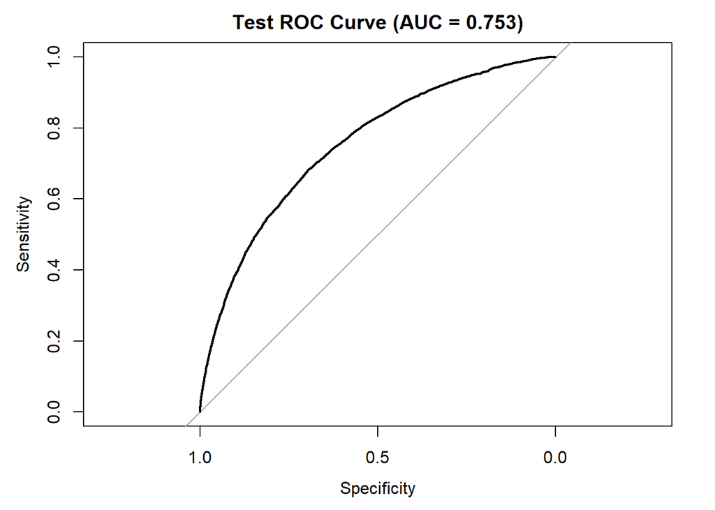

```r
# Plot ROC curve for test set
plot(roc_obj_test, main = paste0("Test ROC Curve (AUC = ", round(test_auc, 4), ")"))
```

```r
### TRAINING SET EVALUATION ###

# Make predictions on the training set
train_preds <- predict(bst_model, dtrain)
train_pred_labels <- ifelse(train_preds > 0.5, 1, 0)

# Evaluate model performance on training set
train_conf_mat <- confusionMatrix(factor(train_pred_labels), factor(train_label))
cat("Training Set Confusion Matrix:\n")
```

```
## Training Set Confusion Matrix:
```

```r
print(train_conf_mat)
```

```
## Confusion Matrix and Statistics
##
##           Reference
## Prediction      0      1
##          0 225904  19180
##          1    245    680
##
##                Accuracy : 0.921
##                  95% CI : (0.92, 0.9221)
##     No Information Rate : 0.9193
##     P-Value [Acc > NIR] : 0.0006288
##
##                   Kappa : 0.0587
##
##  Mcnemar's Test P-Value : < 2.2e-16
##
##             Sensitivity : 0.99892
##             Specificity : 0.03424
##          Pos Pred Value : 0.92174
##          Neg Pred Value : 0.73514
##              Prevalence : 0.91927
##          Detection Rate : 0.91828
##    Detection Prevalence : 0.99624
##       Balanced Accuracy : 0.51658
##
##        'Positive' Class : 0
##
```

```r
# Extract metrics for training set
train_accuracy <- train_conf_mat$overall["Accuracy"]
train_precision <- train_conf_mat$byClass["Pos Pred Value"]
train_recall <- train_conf_mat$byClass["Sensitivity"]
train_f1_score <- 2 * ((train_precision * train_recall) / (train_precision + train_recall))

# Compute ROC and AUC for training set
roc_obj_train <- roc(train_label, train_preds)
train_auc <- auc(roc_obj_train)

# Display training set metrics
cat("Training Set Performance:\n")
```

```
## Training Set Performance:
```

```r
cat("Accuracy:", round(train_accuracy, 4), "\n")
```

```
## Accuracy: 0.921
```

```r
cat("Precision:", round(train_precision, 4), "\n")
```

```
## Precision: 0.9217
```

```r
cat("Recall:", round(train_recall, 4), "\n")
```

```
## Recall: 0.9989
```

```r
cat("F1 Score:", round(train_f1_score, 4), "\n")
```

```
## F1 Score: 0.9588
```

```r
cat("AUC:", round(train_auc, 4), "\n")
```

```
## AUC: 0.7942
```

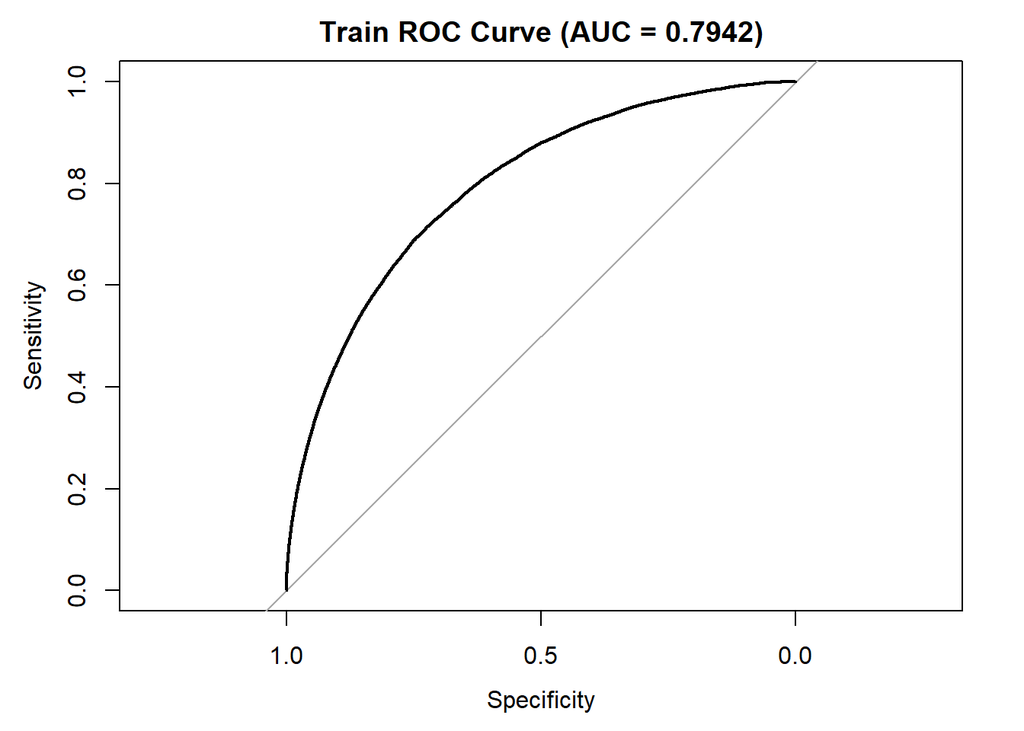

```r
# Plot ROC curve for training set
plot(roc_obj_train, main = paste0("Train ROC Curve (AUC = ", round(train_auc, 4), ")"))
```

# Naive Bayes

```r
# Default model

nb_df <- naiveBayes(TARGET ~ .,data = df_train)
```

```r
nb_df_train_predictions <- predict(nb_df,df_train)
nb_df_test_predictions <- predict(nb_df,df_test)
```

```r
mmetric(df_train$TARGET, nb_df_train_predictions, metric=c("ACC","F1","TPR"))
```

```
##      ACC      F11      F12     TPR1     TPR2
## 65.80213 78.03918 22.76523 66.09831 62.42951
```

```r
mmetric(df_test$TARGET, nb_df_test_predictions, metric=c("ACC","F1","TPR"))
```

```
##      ACC      F11      F12     TPR1     TPR2
## 65.54438 77.82351 22.79705 65.76617 63.01867
```

```r
# Adjusted model after removing document variables

nb_df2 <- naiveBayes(TARGET ~ EXT_SOURCE_3 + AMT_REQ_CREDIT_BUREAU_MON + AMT_REQ_CREDIT_BUREAU_QRT + AMT_REQ_CREDIT_BUREAU_YEAR + OBS_30_CNT_SOCIAL_CIRCLE + DEF_30_CNT_SOCIAL_CIRCLE + DEF_60_CNT_SOCIAL_CIRCLE + EXT_SOURCE_2 + AMT_ANNUITY + CNT_FAM_MEMBERS + DAYS_LAST_PHONE_CHANGE + NAME_CONTRACT_TYPE + CODE_GENDER + FLAG_OWN_CAR + FLAG_OWN_REALTY + AMT_CREDIT + NAME_TYPE_SUITE + NAME_INCOME_TYPE + NAME_EDUCATION_TYPE + NAME_FAMILY_STATUS + NAME_HOUSING_TYPE + REGION_POPULATION_RELATIVE + DAYS_BIRTH + DAYS_ID_PUBLISH + FLAG_EMP_PHONE + FLAG_WORK_PHONE + FLAG_PHONE + OCCUPATION_TYPE + REGION_RATING_CLIENT + REGION_RATING_CLIENT_W_CITY + HOUR_APPR_PROCESS_START + REG_REGION_NOT_LIVE_REGION + REG_REGION_NOT_WORK_REGION + REG_CITY_NOT_LIVE_CITY + REG_CITY_NOT_WORK_CITY + LIVE_CITY_NOT_WORK_CITY + ORGANIZATION_TYPE + FONDKAPREMONT_MODE + HOUSETYPE_MODE + WALLSMATERIAL_MODE + EMERGENCYSTATE_MODE, data = df_train)
```

```r
nb_df2_train_predictions <- predict(nb_df2,df_train)
nb_df2_test_predictions <- predict(nb_df2,df_test)
```

```r
mmetric(df_train$TARGET, nb_df2_train_predictions, metric=c("ACC","F1","TPR"))
```

```
##      ACC      F11      F12     TPR1     TPR2
## 82.45416 90.09273 23.37857 86.78347 33.15687
```

```r
mmetric(df_test$TARGET, nb_df2_test_predictions, metric=c("ACC","F1","TPR"))
```

```
##      ACC      F11      F12     TPR1     TPR2
## 82.33317 90.01311 23.51947 86.60810 33.65113
```

### Two different Naive Bayes models are used for the Home Credit data. The first utilizes all available predictor variables, and results in an accuracy of 65%. The second uses all predictor variables except for document variables, and results in an accuracy of 82%, which still underperforms the majority based classifier.

# Cross Validation

```r
cv_function <- function(df, target, nFolds, seedVal, classification, metrics_list)
{

  set.seed(seedVal)
  folds = createFolds(df[,target],nFolds)
  # folds

 cv_results <- lapply(folds, function(x)
 {
   train <- df[-x,-target]
   test  <- df[x,-target]

   train_target <- df[-x,target]
   test_target <- df[x,target]

   classification_model <- classification(train,train_target)

   pred <- predict(classification_model,test)

   return(mmetric(test_target,pred,metrics_list))
 })

 cv_results_m <- as.matrix(as.data.frame(cv_results))

 cv_mean<- as.matrix(rowMeans(cv_results_m))

 colnames(cv_mean) <- "Mean"

 cv_sd <- as.matrix(rowSds(cv_results_m))

 colnames(cv_sd) <- "Sd"

 cv_all <- cbind(cv_results_m, cv_mean, cv_sd)

 kable(cv_all,digits=2)
}
```

```r
metrics_list <- c("ACC","F1","TPR")

cv_function(metrics_list =  metrics_list, df = df_train, target = 12, nFolds = 5, seed = 22, classification =  naiveBayes)
```

|  | Fold1 | Fold2 | Fold3 | Fold4 | Fold5 | Mean | Sd |
| --- | --- | --- | --- | --- | --- | --- | --- |
| ACC | 65.11 | 65.79 | 65.67 | 62.20 | 68.59 | 65.47 | 2.27 |
| F11 | 77.52 | 78.01 | 77.94 | 75.03 | 80.26 | 77.75 | 1.86 |
| F12 | 22.12 | 22.92 | 22.61 | 22.29 | 23.12 | 22.61 | 0.42 |
| TPR1 | 65.43 | 66.03 | 65.98 | 61.76 | 69.47 | 65.74 | 2.74 |
| TPR2 | 61.36 | 63.00 | 62.11 | 67.17 | 58.50 | 62.43 | 3.14 |

```r
cv_function(metrics_list =  metrics_list, df = df_train, target = 12, nFolds = 10, seed = 22, classification =  naiveBayes)
```

|  | Fold01 | Fold02 | Fold03 | Fold04 | Fold05 | Fold06 | Fold07 | Fold08 | Fold09 | Fold10 | Mean | Sd |
| --- | --- | --- | --- | --- | --- | --- | --- | --- | --- | --- | --- | --- |
| ACC | 65.43 | 65.07 | 64.15 | 66.35 | 65.57 | 66.34 | 65.57 | 64.50 | 67.19 | 67.01 | 65.72 | 1.00 |
| F11 | 77.72 | 77.45 | 76.71 | 78.48 | 77.92 | 78.45 | 77.87 | 76.97 | 79.17 | 78.96 | 77.97 | 0.81 |
| F12 | 22.93 | 22.60 | 22.25 | 22.86 | 21.95 | 23.21 | 22.52 | 22.56 | 22.68 | 23.67 | 22.72 | 0.48 |
| TPR1 | 65.58 | 65.24 | 64.21 | 66.76 | 66.07 | 66.64 | 65.89 | 64.54 | 67.85 | 67.33 | 66.01 | 1.17 |
| TPR2 | 63.69 | 63.18 | 63.52 | 61.74 | 59.95 | 63.00 | 61.97 | 64.04 | 59.64 | 63.39 | 62.41 | 1.56 |

# Results